# Trabajo Final

Trabajo Final Melina Schamberger Diciembre, 2021

## Buenos Aires: envejecimiento poblacional en el período 2001-2010.

### Objetivos

El presente reporte busca caracterizar el **proceso de envejecimiento poblacional** de la provincia de **Buenos Aires**, a partir de los datos censales correspondientes a los años 2001 y 2010.

Para ello, se proponen los siguientes *objetivos específicos*:

- Comparar la distribución poblacional de la provincia, según sexo y edad de la población en los distintos momentos del tiempo.
- Analizar la dirección y la magnitud del aumento de personas de 60 años y más en el período bajo estudio.

##### Envejecimiento

Cabe mencionar que, según la [CELADE](https://www.cepal.org/es/temas/envejecimiento), el envejecimiento se define como el aumento progresivo de la proporción de las personas de 60 años y más con respecto a la población total.

### Análisis de datos

A fin de concretar los objetivos propuestos, es preciso considerar el tamaño total de la población de Buenos Aires en los dos momentos del tiempo:

- En 2001, la población total asciende a **13.827.203** personas;
- Mientras que, en 2010, la población total es igual a **15.625.084** personas.

##### Pirámides de población

Asimismo, resulta relevante indagar la distribución por edad y sexo de la población en ambos años.

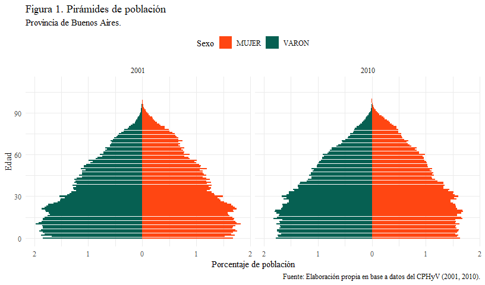

##### Indice de masculinidad

Por último, se indaga en el índice de masculinidad. Este, es un índice demográfico que expresa la razón de hombres por mujeres en un determinado territorio, expresada en tanto por ciento.

Su cálculo es el siguiente:

$(Total \ de \ Varones / \ Total \ de \ mujeres) * 100$

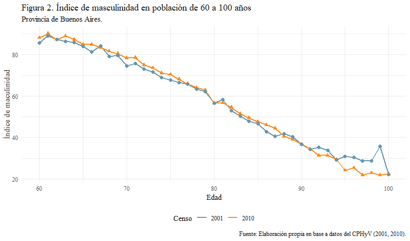

### Resultados

De los datos expuestos en la Figura 1, surge que la provincia registra cierta estabilidad en la dinámica poblacional del período bajo estudio. Sin embargo, en el año 2010, puede apreciarse una leve tendencia de suba en las mujeres de edad avanzada.

En consecuencia, es posible pensar que en la población de Buenos Aires existe cierta estabilidad, aunque podría advertirse un **leve** proceso de envejecimiento poblacional en las mujeres.